# Tutorial 7: Comparar, relacionar y correlacionar variables

Estadística I — Matemáticas Aplicadas y Computación

Dra. Elizabeth Martínez Gómez

# Propósito

Cerramos el Tema 1 pasando de estudiar una variable a estudiar **relaciones entre variables**.

Trabajaremos con datos reales del NIST sobre calibración de un sistema óptico y con las mediciones históricas de Michelson.

El conjunto de calibración contiene 40 mediciones de 10 artefactos de ancho de línea; la primera columna es el ancho de referencia y la segunda el ancho medido. [NIST, CALIBRATIONLINE.DAT](https://www.itl.nist.gov/div898/handbook/datasets/CALIBRATIONLINE.DAT).

```r
knitr::opts_chunk$set(echo = TRUE, message = FALSE, warning = FALSE)
library(ggplot2)

setwd("/home/nani/Documents/Universidad/2027-I/Estadistica/Actividades/Tutoriales estadística")
cal <- read.csv("Datos/Dana Amador - CALIBRATIONLINE.csv")
attach(cal)
names(cal)
```

```
## [1] "ancho_referencia" "ancho_medido"     "medicion_3"       "medicion_4"
## [5] "medicion_5"
```

```r
michelson <- read.csv("Datos/Dana Amador - MICHELSO.csv")
attach(michelson)
names(michelson)
```

```
## [1] "SPEED.OF.LIGHT" "TEMP"           "DAY"            "AMPM"
## [5] "SET"
```

```r
names(michelson)<- c("velocidad", "temperatura", "dia", "ampm")
```

# 1. Comparación y asociación no son lo mismo

### Comparación

Pregunta:

> ¿Cómo cambia una variable entre grupos?

Ejemplo:

> ¿Los diámetros difieren entre máquinas?

### Asociación

Pregunta:

> ¿Cómo varía una variable cuando cambia otra?

Ejemplo:

> ¿Cómo se relaciona el ancho medido con el ancho de referencia?

# 2. La gráfica de dispersión

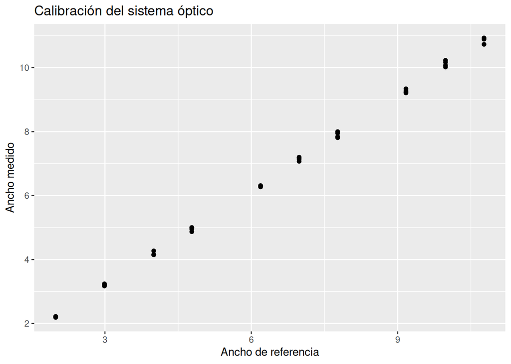

```r
ggplot(cal, aes(x = ancho_referencia, y = ancho_medido)) +
  geom_point() +
  labs(
    title = "Calibración del sistema óptico",
    x = "Ancho de referencia",
    y = "Ancho medido"
  )
```

Antes de calcular un número, observa.

## Actividad 1

Describe:

1. dirección;
2. intensidad aparente;
3. linealidad;
4. posibles puntos alejados;
5. posible sesgo sistemático.

# 3. Covarianza

La covarianza muestral es:

$$s_{XY}
=
\frac{1}{n-1}
\sum_{i=1}^{n}
(x_i-\bar x)(y_i-\bar y).$$

```r
cov(cal$ancho_referencia, cal$ancho_medido)
```

```
## [1] 8.22691
```

El signo informa sobre la dirección conjunta:

- positiva: valores grandes de $X$ tienden a acompañarse de valores grandes de $Y$;
- negativa: valores grandes de $X$ tienden a acompañarse de valores pequeños de $Y$.

Pero la magnitud depende de las unidades.

# 4. Correlación de Pearson

$$r=
\frac{s_{XY}}{s_Xs_Y}.$$

```r
cor(cal$ancho_referencia, cal$ancho_medido)
```

```
## [1] 0.9997692
```

Como $r$ es adimensional, permite interpretar la intensidad lineal en una escala común.

# 5. Interpretar $r$ no significa memorizar intervalos

Un valor cercano a 1 indica asociación lineal positiva fuerte.

Un valor cercano a -1 indica asociación lineal negativa fuerte.

Un valor cercano a 0 indica poca asociación **lineal**.

Pero:

$$r\approx0$$

no significa necesariamente independencia ni ausencia de relación.

# 6. Actividad 2 — Correlación alta no significa medición perfecta

Calcula:

```r
cor(cal$ancho_referencia, cal$ancho_medido)
```

```
## [1] 0.9997692
```

Ahora calcula el error de medición:

```r
cal$error <- cal$ancho_medido - cal$ancho_referencia

summary(cal$error)
```

```
##    Min. 1st Qu.  Median    Mean 3rd Qu.    Max.
##  -0.040   0.090   0.160   0.152   0.220   0.270
```

Y grafícalo:

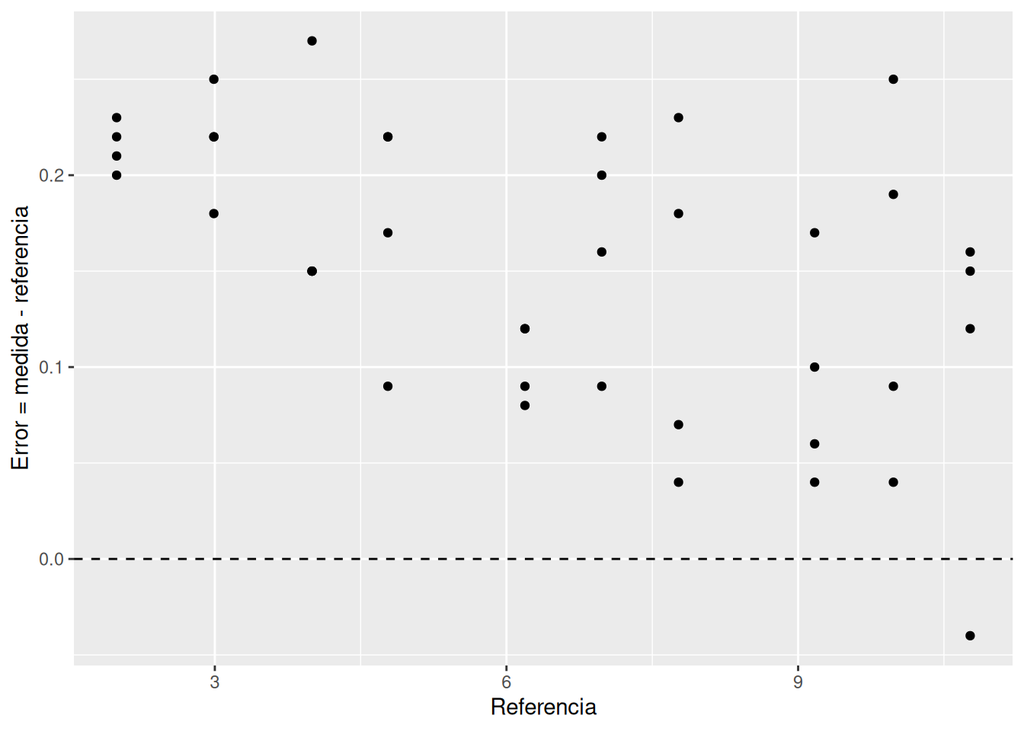

```r
ggplot(cal, aes(x = ancho_referencia, y = error)) +
  geom_point() +
  geom_hline(yintercept = 0, linetype = 2) +
  labs(
    x = "Referencia",
    y = "Error = medida - referencia"
  )
```

### Pregunta importante

¿Una correlación alta garantiza que el instrumento sea insesgado?

**No. La correlación mide asociación lineal, no necesariamente acuerdo entre dos métodos de medición distintos.**

# 7. Un ejemplo histórico diferente

En el conjunto de Michelson tenemos temperatura y velocidad medida:

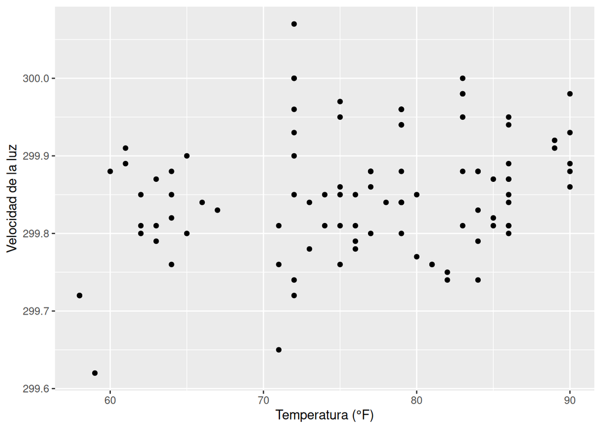

```r
ggplot(michelson, aes(x = temperatura, y = velocidad)) +
  geom_point() +
  labs(
    x = "Temperatura (°F)",
    y = "Velocidad de la luz"
  )
```

Calcula:

```r
cor(michelson$temperatura, michelson$velocidad)
```

```
## [1] 0.2649034
```

## Actividad 3

Compara la gráfica con la correlación.

¿El número cuenta toda la historia?

¿Qué deberíamos revisar antes de interpretar el coeficiente?

# 8. Correlación y causalidad

Supón que observamos una correlación entre $X$ y $Y$.

No podemos concluir automáticamente:

$$X\rightarrow Y.$$

Puede existir:

- una variable de confusión;
- causalidad inversa;
- asociación accidental;
- estructura temporal;
- selección de datos.

## Actividad 4

Escribe un ejemplo propio de dos variables correlacionadas donde ninguna cause necesariamente a la otra.

Después explica qué variable adicional podría actuar como confusora.

# 9. Una correlación puede ocultar estructura

Considera la identidad:

$$Y=X^2$$

con $X$ distribuida aproximadamente de forma simétrica alrededor de cero.

Puede existir una relación determinista muy fuerte entre $X$ y $Y$, pero la correlación lineal puede ser cercana a cero.

Puedes comprobarlo:

```r
set.seed(10)

x <- seq(-3, 3, length.out = 100)
y <- x^2

cor(x, y)
```

```
## [1] 1.239961e-16
```

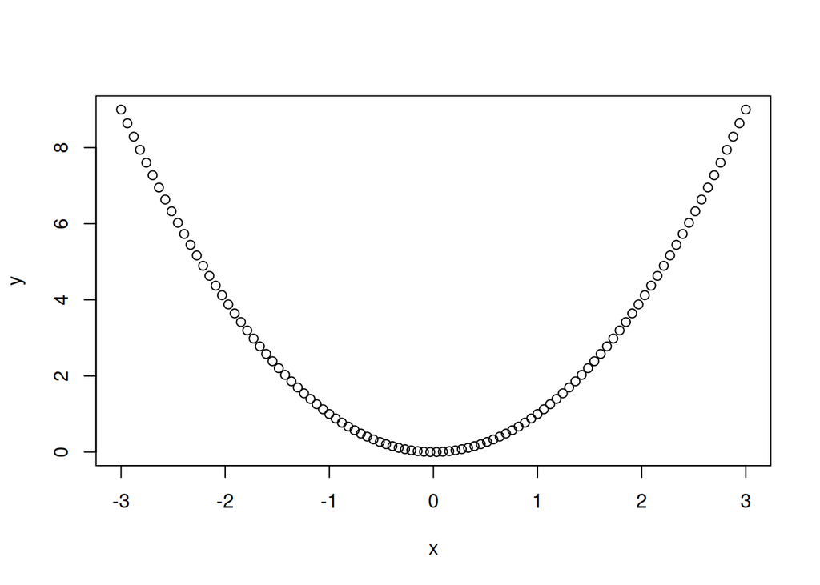

```r
plot(x, y)
```

## Actividad 5

Explica:

> ¿Cómo puede existir una relación matemática fuerte y, al mismo tiempo, una correlación de Pearson cercana a cero?

Esto es fundamental:

> **Pearson mide asociación lineal.**

# 10. Comparación final: tres preguntas distintas

Ante un conjunto de datos debes decidir qué problema tienes:

### Problema A — Descripción

> ¿Cómo se distribuye $X$?

Usamos:

- histogramas;
- boxplots;
- media;
- mediana;
- cuantiles;
- dispersión.

### Problema B — Comparación

> ¿Cómo cambia $X$ entre grupos?

Usamos:

- tablas;
- boxplots;
- medidas por grupo.

### Problema C — Asociación

> ¿Cómo se relacionan $X$ y $Y$?

Usamos:

- dispersión;
- covarianza;
- correlación;
- análisis de la forma de la relación.

# Actividad integradora del Tema 1

Escoge **uno** de los conjuntos de datos trabajados en los siete tutoriales. Si no fueron de tu agrado, puedes elegir otro.

Construye un mini análisis estadístico de una página que contenga:

## 1. Problema

Formula una pregunta estadística clara.

## 2. Datos

Indica:

- fuente;
- unidad estadística;
- variables;
- población de interés;
- muestra disponible.

## 3. Exploración

Incluye al menos:

- una tabla;
- una gráfica univariada;
- una gráfica comparativa o bivariada, según corresponda.

## 4. Resumen numérico

Incluye medidas apropiadas de:

- centro;
- posición;
- dispersión;
- forma.

## 5. Interpretación

Responde la pregunta inicial.

## 6. Limitaciones

Indica qué conclusión **no** puede obtenerse a partir de los datos.

# Reto final

Explica con tus propias palabras la siguiente cadena:

$$\boxed{
\text{pregunta}
\rightarrow
\text{datos}
\rightarrow
\text{estructura}
\rightarrow
\text{gráficas}
\rightarrow
\text{medidas}
\rightarrow
\text{interpretación}
}$$

Tu explicación debe mostrar que entiendes que **una estadística no tiene significado fuera del problema estadístico que la originó**.

# Autoevaluación

**Checklist final**

Al terminar el Tema 1 deberías poder:

- identificar población y muestra;
- distinguir variable y observación;
- clasificar variables;
- reconocer escalas de medición;
- construir e interpretar tablas;
- elegir gráficas adecuadas;
- interpretar media, mediana y cuantiles;
- interpretar rango, IQR, varianza y desviación estándar;
- describir forma, asimetría y curtosis;
- comparar distribuciones;
- distinguir comparación de asociación;
- calcular e interpretar covarianza;
- calcular e interpretar correlación de Pearson;
- explicar por qué correlación no implica causalidad;
- reconocer que Pearson mide asociación lineal.